# BA 64060 Assignment 5

Madeline Witzeman

2023-11-24

# Load any potential required packages (after they’ve already been installed)

```r
library(tidyverse)
library(factoextra)
library(cluster)
library(dplyr)
library(caret)
library(ISLR)
library(class)
```

# Data Preprocessing: remove the cereals with missing values; set cereal names as row names. For the purposes of this clustering analysis, I also removed the non-numerical variables.

```r
cereal.ds2 <- na.omit(cereal.ds)
row.names(cereal.ds2) <- cereal.ds2[,1]
cereal.ds2 <- cereal.ds2[,c(4,5,6,7,8,9,10,11,12,13,14,15,16)]
head(cereal.ds2)
```

```
##                           calories protein fat sodium fiber carbo sugars potass
## 100%_Bran                       70       4   1    130  10.0   5.0      6    280
## 100%_Natural_Bran              120       3   5     15   2.0   8.0      8    135
## All-Bran                        70       4   1    260   9.0   7.0      5    320
## All-Bran_with_Extra_Fiber       50       4   0    140  14.0   8.0      0    330
## Apple_Cinnamon_Cheerios        110       2   2    180   1.5  10.5     10     70
## Apple_Jacks                    110       2   0    125   1.0  11.0     14     30
##                           vitamins shelf weight cups   rating
## 100%_Bran                       25     3      1 0.33 68.40297
## 100%_Natural_Bran                0     3      1 1.00 33.98368
## All-Bran                        25     3      1 0.33 59.42551
## All-Bran_with_Extra_Fiber       25     3      1 0.50 93.70491
## Apple_Cinnamon_Cheerios         25     1      1 0.75 29.50954
## Apple_Jacks                     25     2      1 1.00 33.17409
```

# Step 1: Apply hierarchical clustering to the data using Euclidean distance to the normalized measurements. Use Agnes to compare the clustering from single linkage, complete linkage, average linkage, and Ward. Choose the best method.

# Normalize the data:

```r
norm.cereal.ds2 <- scale(cereal.ds2)
head(cereal.ds2)
```

```
##                           calories protein fat sodium fiber carbo sugars potass
## 100%_Bran                       70       4   1    130  10.0   5.0      6    280
## 100%_Natural_Bran              120       3   5     15   2.0   8.0      8    135
## All-Bran                        70       4   1    260   9.0   7.0      5    320
## All-Bran_with_Extra_Fiber       50       4   0    140  14.0   8.0      0    330
## Apple_Cinnamon_Cheerios        110       2   2    180   1.5  10.5     10     70
## Apple_Jacks                    110       2   0    125   1.0  11.0     14     30
##                           vitamins shelf weight cups   rating
## 100%_Bran                       25     3      1 0.33 68.40297
## 100%_Natural_Bran                0     3      1 1.00 33.98368
## All-Bran                        25     3      1 0.33 59.42551
## All-Bran_with_Extra_Fiber       25     3      1 0.50 93.70491
## Apple_Cinnamon_Cheerios         25     1      1 0.75 29.50954
## Apple_Jacks                     25     2      1 1.00 33.17409
```

# Use Agnes to compare the clustering from single linkage, complete linkage, average linkage, and Ward; choose the best method

```r
hc_single <- agnes(norm.cereal.ds2, method = "single")
hc_complete <- agnes(norm.cereal.ds2, method = "complete")
hc_average <- agnes(norm.cereal.ds2, method = "average")
hc_Ward <- agnes(norm.cereal.ds2, method = "ward")
print(hc_single$ac)
```

```
## [1] 0.6067859
```

```r
print(hc_complete$ac)
```

```
## [1] 0.8353712
```

```r
print(hc_average$ac)
```

```
## [1] 0.7766075
```

```r
print(hc_Ward$ac)
```

```
## [1] 0.9046042
```

# Based on the agglomerative coefficients above, the Ward’s method is the best

# Apply hierarchical clustering to the data using Euclidean distance to the normalized measurements and the Ward’s method for clustering

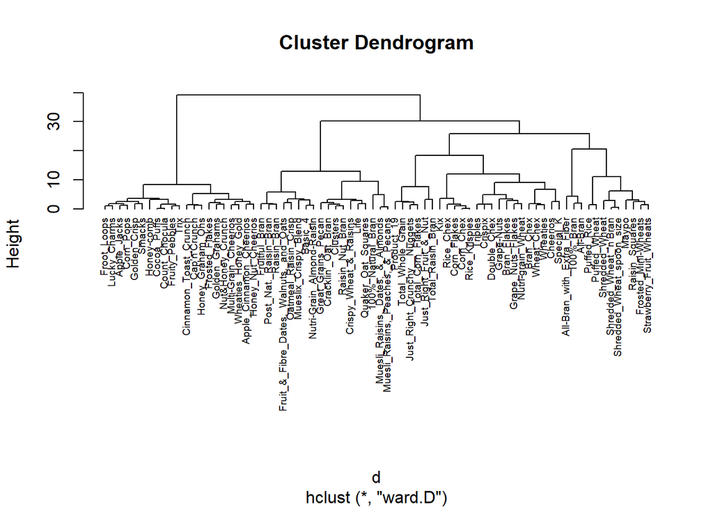

```r
d <- dist(norm.cereal.ds2, method = "euclidean")
hc1 <- hclust(d, method = "ward.D" )
plot(hc1, cex = 0.6, hang = -1)
```

# Step 2: How many clusters would you choose?

# I would choose 4 clusters based on the hierarchical clustering output above:

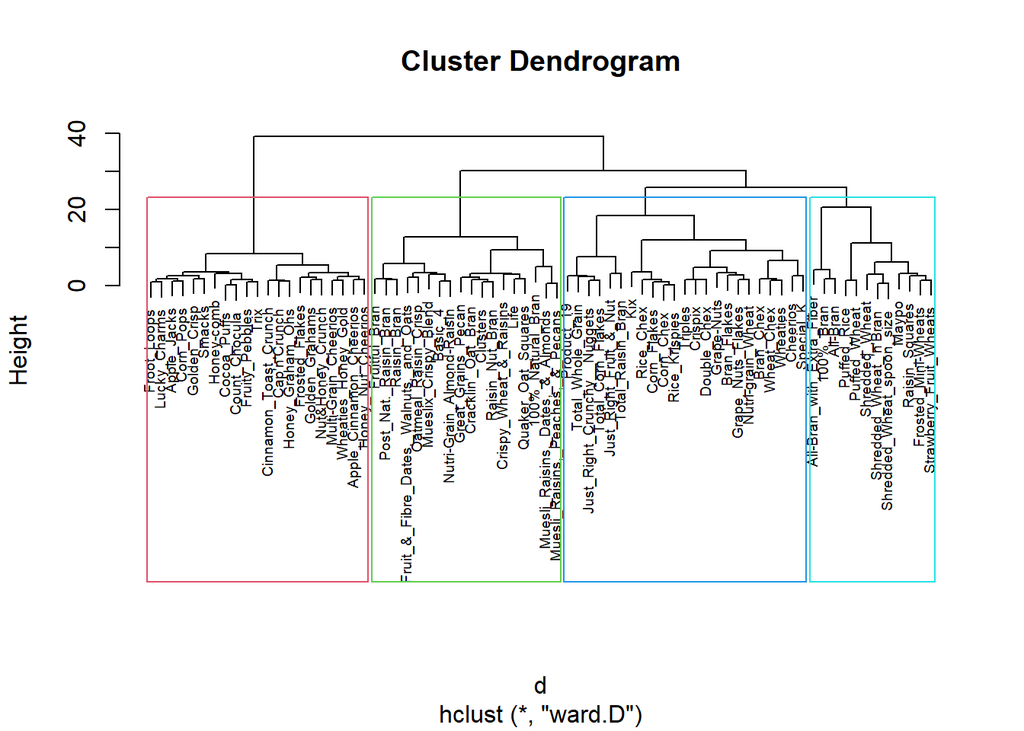

```r
plot(hc1, cex = 0.6)
rect.hclust(hc1, k = 4, border = 2:5)
```

```r
memb1 <- cutree(hc1, k = 4)
memb1
```

```
##                              100%_Bran                      100%_Natural_Bran
##                                      1                                      2
##                               All-Bran              All-Bran_with_Extra_Fiber
##                                      1                                      1
##                Apple_Cinnamon_Cheerios                            Apple_Jacks
##                                      3                                      3
##                                Basic_4                              Bran_Chex
##                                      2                                      4
##                            Bran_Flakes                           Cap'n'Crunch
##                                      4                                      3
##                               Cheerios                  Cinnamon_Toast_Crunch
##                                      4                                      3
##                               Clusters                            Cocoa_Puffs
##                                      2                                      3
##                              Corn_Chex                            Corn_Flakes
##                                      4                                      4
##                              Corn_Pops                          Count_Chocula
##                                      3                                      3
##                     Cracklin'_Oat_Bran                                Crispix
##                                      2                                      4
##                 Crispy_Wheat_&_Raisins                            Double_Chex
##                                      2                                      4
##                            Froot_Loops                         Frosted_Flakes
##                                      3                                      3
##                    Frosted_Mini-Wheats Fruit_&_Fibre_Dates,_Walnuts,_and_Oats
##                                      1                                      2
##                          Fruitful_Bran                         Fruity_Pebbles
##                                      2                                      3
##                           Golden_Crisp                         Golden_Grahams
##                                      3                                      3
##                      Grape_Nuts_Flakes                             Grape-Nuts
##                                      4                                      4
##                     Great_Grains_Pecan                       Honey_Graham_Ohs
##                                      2                                      3
##                     Honey_Nut_Cheerios                             Honey-comb
##                                      3                                      3
##            Just_Right_Crunchy__Nuggets                 Just_Right_Fruit_&_Nut
##                                      4                                      4
##                                    Kix                                   Life
##                                      4                                      2
```

[output cut: 19 more lines]

```
##                                      4                                      4
##                         Shredded_Wheat                 Shredded_Wheat_'n'Bran
##                                      1                                      1
##              Shredded_Wheat_spoon_size                                 Smacks
##                                      1                                      3
##                              Special_K                Strawberry_Fruit_Wheats
##                                      4                                      1
##                      Total_Corn_Flakes                      Total_Raisin_Bran
##                                      4                                      4
##                      Total_Whole_Grain                                Triples
##                                      4                                      4
##                                   Trix                             Wheat_Chex
##                                      3                                      4
##                               Wheaties                    Wheaties_Honey_Gold
##                                      4                                      3
```

# Step 3: Comment on the structure of the clusters and on their stability

# The clusters vary in size from roughly 12 to 25 data points. The red cluster (Cluster 3) seems to be characterized by below average fiber & potassium and above average sugar. The green cluster (Cluster 2) is characterized by above average calories, fat, fiber, potassium and average to above average sugar. The dark blue cluster (Cluster 4) is characterized by average to below average fat, below average sugar, and above average sodium & carbohydrates. Lastly, the aqua cluster (Cluster 1) is characterized by below average calories, fat, sodium, & sugar, mostly above average protein, fiber, potassium, & rating, and average vitamins.

# Testing the stability:

# Partitioning the data (70% Partition A, 30% Partition B)

```r
set.seed(18)
names(norm.cereal.ds2) <- c('calories', 'protein', 'fat', 'sodium', 'fiber', 'carbo', 'sugars', 'potass', 'vitamins', 'shelf', 'weight', 'cups', 'rating')
df.norm.cereal.ds2<- as.data.frame(norm.cereal.ds2)

PartA_Index_Cereal = createDataPartition(df.norm.cereal.ds2$calories, p=0.7, list=FALSE)
PartA_Data_Cereal = df.norm.cereal.ds2[PartA_Index_Cereal,]
PartB_Data_Cereal = df.norm.cereal.ds2[-PartA_Index_Cereal,]
```

# Cluster training data (Partition A)

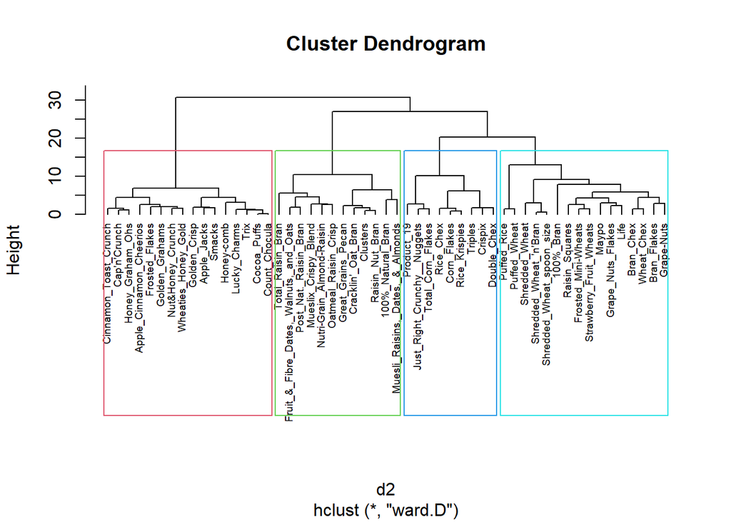

```r
d2 <- dist(PartA_Data_Cereal, method = "euclidean")
hc2 <- hclust(d2, method = "ward.D" )
plot(hc2, cex = 0.6, hang = -1)
rect.hclust(hc2, k = 4, border = 2:5)
```

```r
memb2 <- cutree(hc2, k = 4)
memb2
```

```
##                              100%_Bran                      100%_Natural_Bran
##                                      1                                      2
##                Apple_Cinnamon_Cheerios                            Apple_Jacks
##                                      3                                      3
##                              Bran_Chex                            Bran_Flakes
##                                      1                                      1
##                           Cap'n'Crunch                  Cinnamon_Toast_Crunch
##                                      3                                      3
##                               Clusters                            Cocoa_Puffs
##                                      2                                      3
##                            Corn_Flakes                          Count_Chocula
##                                      4                                      3
##                     Cracklin'_Oat_Bran                                Crispix
##                                      2                                      4
##                            Double_Chex                         Frosted_Flakes
##                                      4                                      3
##                    Frosted_Mini-Wheats Fruit_&_Fibre_Dates,_Walnuts,_and_Oats
##                                      1                                      2
##                           Golden_Crisp                         Golden_Grahams
##                                      3                                      3
##                      Grape_Nuts_Flakes                             Grape-Nuts
##                                      1                                      1
##                     Great_Grains_Pecan                       Honey_Graham_Ohs
##                                      2                                      3
##                             Honey-comb            Just_Right_Crunchy__Nuggets
##                                      3                                      4
##                                   Life                           Lucky_Charms
##                                      1                                      3
##                                  Maypo       Muesli_Raisins,_Dates,_&_Almonds
##                                      1                                      2
##                   Mueslix_Crispy_Blend                       Nut&Honey_Crunch
##                                      2                                      3
##              Nutri-Grain_Almond-Raisin                   Oatmeal_Raisin_Crisp
##                                      2                                      2
##                  Post_Nat._Raisin_Bran                             Product_19
##                                      2                                      4
##                            Puffed_Rice                           Puffed_Wheat
##                                      1                                      1
##                        Raisin_Nut_Bran                         Raisin_Squares
##                                      2                                      1
##                              Rice_Chex                          Rice_Krispies
##                                      4                                      4
##                         Shredded_Wheat                 Shredded_Wheat_'n'Bran
##                                      1                                      1
##              Shredded_Wheat_spoon_size                                 Smacks
##                                      1                                      3
##                Strawberry_Fruit_Wheats                      Total_Corn_Flakes
##                                      1                                      4
##                      Total_Raisin_Bran                                Triples
##                                      2                                      4
##                                   Trix                             Wheat_Chex
##                                      3                                      1
##                    Wheaties_Honey_Gold
##                                      3
```

# Use the cluster centroids from Partition A to assign each record in Partition B (each record is assigned to the cluster with the closest centroid).

# Compute the mean/average for each numerical variable in each cluster in partition A (centroids for Partition A).

```r
membA <- cutree(hc2, k = 4)
membA
```

```
##                              100%_Bran                      100%_Natural_Bran
##                                      1                                      2
##                Apple_Cinnamon_Cheerios                            Apple_Jacks
##                                      3                                      3
##                              Bran_Chex                            Bran_Flakes
##                                      1                                      1
##                           Cap'n'Crunch                  Cinnamon_Toast_Crunch
##                                      3                                      3
##                               Clusters                            Cocoa_Puffs
##                                      2                                      3
##                            Corn_Flakes                          Count_Chocula
##                                      4                                      3
##                     Cracklin'_Oat_Bran                                Crispix
##                                      2                                      4
##                            Double_Chex                         Frosted_Flakes
##                                      4                                      3
##                    Frosted_Mini-Wheats Fruit_&_Fibre_Dates,_Walnuts,_and_Oats
##                                      1                                      2
##                           Golden_Crisp                         Golden_Grahams
##                                      3                                      3
##                      Grape_Nuts_Flakes                             Grape-Nuts
##                                      1                                      1
##                     Great_Grains_Pecan                       Honey_Graham_Ohs
##                                      2                                      3
##                             Honey-comb            Just_Right_Crunchy__Nuggets
##                                      3                                      4
##                                   Life                           Lucky_Charms
##                                      1                                      3
##                                  Maypo       Muesli_Raisins,_Dates,_&_Almonds
##                                      1                                      2
##                   Mueslix_Crispy_Blend                       Nut&Honey_Crunch
##                                      2                                      3
##              Nutri-Grain_Almond-Raisin                   Oatmeal_Raisin_Crisp
##                                      2                                      2
##                  Post_Nat._Raisin_Bran                             Product_19
##                                      2                                      4
##                            Puffed_Rice                           Puffed_Wheat
##                                      1                                      1
##                        Raisin_Nut_Bran                         Raisin_Squares
##                                      2                                      1
##                              Rice_Chex                          Rice_Krispies
##                                      4                                      4
##                         Shredded_Wheat                 Shredded_Wheat_'n'Bran
##                                      1                                      1
##              Shredded_Wheat_spoon_size                                 Smacks
##                                      1                                      3
##                Strawberry_Fruit_Wheats                      Total_Corn_Flakes
##                                      1                                      4
##                      Total_Raisin_Bran                                Triples
##                                      2                                      4
##                                   Trix                             Wheat_Chex
##                                      3                                      1
##                    Wheaties_Honey_Gold
##                                      3
```

```r
PartA_Centroids <- aggregate(PartA_Data_Cereal,list(cluster=membA),mean)
PartA_Centroids
```

```
##   cluster    calories    protein         fat     sodium      fiber       carbo
## 1       1 -0.98403208  0.2198235 -0.55868640 -1.0215366  0.3659435 -0.05903107
## 2       2  0.98970700  0.5296700  1.32429368 -0.2551035  0.4433144 -0.35881633
## 3       3  0.24430554 -1.0001970  0.06207627  0.1526540 -0.7301445 -0.54885876
## 4       4 -0.01815976 -0.4773310 -0.66214684  0.9513888 -0.6685343  1.46844617
##       sugars     potass     vitamins      shelf     weight       cups
## 1 -0.8420542  0.1929210 -0.532267276 -0.1096260 -0.6774791 -0.3621810
## 2  0.5295939  0.8557320  0.005051172  0.9419715  0.9724518 -0.6538464
## 3  1.0075200 -0.7638194 -0.181842201 -0.6354247 -0.2008324  0.2609223
## 4 -0.8659505 -0.7471634  0.939518040  0.1407544 -0.2008324  0.5823434
##        rating
## 1  1.16067578
## 2 -0.36916975
## 3 -1.06586948
## 4 -0.04531963
```

# Find which cluster in partition A has the closest/smallest Euclidean distance to each observation in partition B.

```r
PartA_Centroids_adj <- PartA_Centroids[,2:14]
PartB_Data_Cereal_df <- as.data.frame(PartB_Data_Cereal)
PartACentPartB <- bind_rows(PartA_Centroids_adj, PartB_Data_Cereal_df)
PartACentPartB
```

```
##                                      calories    protein         fat
## ...1                              -0.98403208  0.2198235 -0.55868640
## ...2                               0.98970700  0.5296700  1.32429368
## ...3                               0.24430554 -1.0001970  0.06207627
## ...4                              -0.01815976 -0.4773310 -0.66214684
## All-Bran                          -1.86591549  1.3817478  0.00000000
## All-Bran_with_Extra_Fiber         -2.87378226  1.3817478 -0.99322026
## Basic_4                            1.15768480  0.4522084  0.99322026
## Cheerios                           0.14981803  3.2408266  0.99322026
## Corn_Chex                          0.14981803 -0.4773310 -0.99322026
## Corn_Pops                          0.14981803 -1.4068705 -0.99322026
## Crispy_Wheat_&_Raisins            -0.35411535 -0.4773310  0.00000000
## Froot_Loops                        0.14981803 -0.4773310  0.00000000
## Fruitful_Bran                      0.65375141  0.4522084 -0.99322026
## Fruity_Pebbles                     0.14981803 -1.4068705  0.00000000
## Honey_Nut_Cheerios                 0.14981803  0.4522084  0.00000000
## Just_Right_Fruit_&_Nut             1.66161818  0.4522084  0.00000000
## Kix                                0.14981803 -0.4773310  0.00000000
## Muesli_Raisins,_Peaches,_&_Pecans  2.16555156  1.3817478  1.98644052
## Multi-Grain_Cheerios              -0.35411535 -0.4773310  0.00000000
## Nutri-grain_Wheat                 -0.85804873  0.4522084 -0.99322026
## Quaker_Oat_Squares                -0.35411535  1.3817478  0.00000000
## Raisin_Bran                        0.65375141  0.4522084  0.00000000
## Special_K                          0.14981803  3.2408266 -0.99322026
## Total_Whole_Grain                 -0.35411535  0.4522084  0.00000000
## Wheaties                          -0.35411535  0.4522084  0.00000000
##                                        sodium       fiber       carbo
## ...1                              -1.02153658  0.36594353 -0.05903107
## ...2                              -0.25510353  0.44331445 -0.35881633
## ...3                               0.15265395 -0.73014447 -0.54885876
## ...4                               0.95138877 -0.66853429  1.46844617
## All-Bran                           1.17959872  2.81602258 -1.98622199
## All-Bran_with_Extra_Fiber         -0.27020566  4.87924705 -1.72926320
## Basic_4                            0.57551356 -0.07249167  0.84032469
## Cheerios                           1.54204982 -0.07249167  0.58336590
## Corn_Chex                          1.42123279 -0.89778146  1.86815984
## Corn_Pops                         -0.87429082 -0.48513656 -0.44446926
## Crispy_Wheat_&_Raisins            -0.27020566 -0.07249167 -0.95838683
## Froot_Loops                       -0.45143121 -0.48513656 -0.95838683
## Fruitful_Bran                      0.93796466  1.16544301 -0.18751047
```

[output cut: 49 more lines]

```
## Crispy_Wheat_&_Raisins             0.9419715 -0.2008324 -0.3038480 -0.44147911
## Froot_Loops                       -0.2598542 -0.2008324  0.7567534 -0.72427057
## Fruitful_Bran                      0.9419715  1.9501886 -0.6432404 -0.09664548
## Fruity_Pebbles                    -0.2598542 -0.2008324 -0.3038480 -1.02225423
## Honey_Nut_Cheerios                -1.4616799 -0.2008324 -0.3038480 -0.80517325
## Just_Right_Fruit_&_Nut             0.9419715  1.7546413 -0.3038480 -0.42043579
## Kix                               -0.2598542 -0.2008324  2.8779561 -0.22308231
## Muesli_Raisins,_Peaches,_&_Pecans  0.9419715 -0.2008324  0.7567534 -0.58658904
## Multi-Grain_Cheerios              -1.4616799 -0.2008324  0.7567534 -0.16145563
## Nutri-grain_Wheat                  0.9419715 -0.2008324  0.7567534  1.23068291
## Quaker_Oat_Squares                 0.9419715 -0.2008324 -1.3644493  0.50878106
## Raisin_Bran                       -0.2598542  1.9501886 -0.3038480 -0.22179377
## Special_K                         -1.4616799 -0.2008324  0.7567534  0.76669214
## Total_Whole_Grain                  0.9419715 -0.2008324  0.7567534  0.30548275
## Wheaties                          -1.4616799 -0.2008324  0.7567534  0.65701831
```

```r
distAB <- get_dist(PartACentPartB, method = "euclidean")
print(distAB)
```

```
##                                        ...1      ...2      ...3      ...4
## ...2                               4.133233
## ...3                               4.063393  3.760579
## ...4                               3.796356  4.587826  3.477495
## All-Bran                           5.491434  5.754852  7.507976  7.561951
## All-Bran_with_Extra_Fiber          6.898967  8.437320 10.009476  9.503081
## Basic_4                            4.715563  2.110380  3.939150  3.877854
## Cheerios                           5.250263  5.576063  5.908862  4.983475
## Corn_Chex                          4.438101  5.628415  3.831518  2.125312
## Corn_Pops                          3.853216  4.487910  1.813138  3.706613
## Crispy_Wheat_&_Raisins             3.010855  2.657432  2.422439  3.817350
## Froot_Loops                        3.908499  3.701596  1.241759  3.902929
## Fruitful_Bran                      4.719879  3.011593  4.564832  4.864962
## Fruity_Pebbles                     4.120616  3.919204  1.000256  3.725673
## Honey_Nut_Cheerios                 3.924266  3.661517  2.197364  3.833620
## Just_Right_Fruit_&_Nut             5.983707  4.146405  5.232951  4.222413
## Kix                                5.014840  5.617427  4.188201  2.706110
## Muesli_Raisins,_Peaches,_&_Pecans  5.300316  2.577269  4.603168  5.212665
## Multi-Grain_Cheerios               3.158543  4.088640  2.344901  2.750526
## Nutri-grain_Wheat                  2.286528  4.490907  4.548561  2.806052
## Quaker_Oat_Squares                 2.444785  2.893018  4.109864  3.993221
## Raisin_Bran                        4.725409  2.710109  4.428739  5.132344
## Special_K                          4.370456  5.541088  5.337424  4.456126
## Total_Whole_Grain                  4.496267  4.594961  5.006544  3.262133
## Wheaties                           2.655237  4.224654  3.680563  2.940126
##                                    All-Bran All-Bran_with_Extra_Fiber   Basic_4
## ...2
## ...3
## ...4
## All-Bran
## All-Bran_with_Extra_Fiber          4.031051
## Basic_4                            6.938644                  9.426274
## Cheerios                           7.417456                  9.224413  5.313822
## Corn_Chex                          8.381189                 10.242543  4.726712
## Corn_Pops                          7.948243                  9.868988  4.654132
## Crispy_Wheat_&_Raisins             5.695683                  8.238662  3.606587
## Froot_Loops                        7.451670                  9.743920  4.114882
## Fruitful_Bran                      5.346821                  7.852352  3.093548
## Fruity_Pebbles                     7.734104                 10.173551  4.129982
## Honey_Nut_Cheerios                 6.382534                  9.149993  3.985432
```

[output cut: 195 more lines]

```
## Crispy_Wheat_&_Raisins
## Froot_Loops
## Fruitful_Bran
## Fruity_Pebbles
## Honey_Nut_Cheerios
## Just_Right_Fruit_&_Nut
## Kix
## Muesli_Raisins,_Peaches,_&_Pecans
## Multi-Grain_Cheerios
## Nutri-grain_Wheat
## Quaker_Oat_Squares
## Raisin_Bran
## Special_K
## Total_Whole_Grain
## Wheaties                                   4.157425
```

# Based on the euclidean distances between the cluster centroids in Partition A and the cereals in Partition B above, the cereals in Partition B would be clustered as the following:

# All-Bran: Cluster 1 (same as original cluster)

# All-Bran_with_Extra_Fiber: Cluster 1 (same as orig cluster)

# Basic_4: Cluster 2 (same as orig cluster)

# Cheerios: Cluster 4 (same as orig cluster)

# Corn_Chex: Cluster 4 (same as orig cluster)

# Corn_Pops: Cluster 3 (same as orig cluster)

# Crispy_Wheat_&_Raisins: Cluster 3 (different - orig cluster is 2)

# Froot_Loops: Cluster 3 (same as orig cluster)

# Fruitful_Bran: Cluster 2 (same as orig cluster)

# Fruity_Pebbles: Cluster 3 (same as orig cluster)

# Honey_Nut_Cheerios: Cluster 3 (same as orig cluster)

# Just_Right_Fruit_&_Nut: Cluster 2 (different - orig cluster is 4)

# Kix: Cluster 4 (same as orig cluster)

# Muesli_Raisins,*Peaches,*&_Pecans: Cluster 2 (same as orig cluster)

# Multi-Grain_Cheerios: Cluster 3 (same as orig cluster)

# Nutri-grain_Wheat: Cluster 1 (different - orig cluster is 4)

# Quaker_Oat_Squares: Cluster 1 (different - orig cluster is 2)

# Raisin_Bran: Cluster 2 (same as orig cluster)

# Special_K: Cluster 1 (different - orig cluster is 4)

# Total_Whole_Grain: Cluster 4 (same as orig cluster)

# Wheaties: Cluster 1 (different - orig cluster is 4)

# When comparing these clusters to the orginal clusters produced based on the whole dataset (during steps 1/2), the clusters seem to be somewhat unstable. Clustering based on different partitions of the data resulted in 6 cereals (28.57% of Partition B) changing clusters.

# (I couldn’t determine how to use a ‘for loop’ to solve this problem so I approached it differently)

# Step 4: Find a cluster of “healthy cereals.” Should the data be normalized? If not, how should they be used in the cluster analysis?

# Yes, the data should be normalized. The distance metrics utilized in hierarchical clustering are highly sensitive to the scale of variables. If not normalized, variables with a larger scale will have a stronger effect on total distance. I’ve already normalized the data during my clustering analysis above.

# I would select the aqua cluster (Cluster 1) as the healthiest cereal category. The cereals in this cluster are predominantly low calories, fat, sodium, & sugar while being higher protein, potassium, & fiber, with average vitamins.